# Airline IBM Regression Project

# Airline IBM Regression Project

## Introduction

This project will include Exploratory data analysis and classification models to analyze the given data and attributes that can predict whether or not a plane will be delayed or on time.

To start this project, I will load in a couple of libraries as well via a Github URL and the “read.csv” function. Since the .csv file was too large to be placed directly into GitHub, I had to use Git LFS to push the file through git into my repository as a prerequisite.

```r
library(tidyverse)
library(ggplot2)
library(hablar)
```

```r
url<- "https://media.githubusercontent.com/media/Wesnahika/Airline-IBM-Regression-Project/main/airline_2m.csv"
airline <- read.csv(url)
```

```r
airline
```

| Year | Quarter | Month | DayofMonth | DayOfWeek | FlightDate | Reporting_Airline | DOT_ID_Reporting_Airline | IATA_CODE_Reporting_Airline | Tail_Number | Flight_Number_Reporting_Airline | OriginAirportID | OriginAirportSeqID | OriginCityMarketID | Origin | OriginCityName | OriginState | OriginStateFips | OriginStateName | OriginWac | DestAirportID | DestAirportSeqID | DestCityMarketID | Dest | DestCityName | DestState | DestStateFips | DestStateName | DestWac | CRSDepTime | … |
| --- | --- | --- | --- | --- | --- | --- | --- | --- | --- | --- | --- | --- | --- | --- | --- | --- | --- | --- | --- | --- | --- | --- | --- | --- | --- | --- | --- | --- | --- | --- |
| 1998 | 1 | 1 | 2 | 5 | 1/2/1998 | NW | 19386 | NW | N297US | 675 | 13487 | 1348701 | 31650 | MSP | Minneapolis, MN | MN | 27 | Minnesota | 63 | 14869 | 1486902 | 34614 | SLC | Salt Lake City, UT | UT | 49 | Utah | 87 | 1640 | … |
| 2009 | 2 | 5 | 28 | 4 | 5/28/2009 | FL | 20437 | FL | N946AT | 671 | 13342 | 1334202 | 33342 | MKE | Milwaukee, WI | WI | 55 | Wisconsin | 45 | 13204 | 1320401 | 31454 | MCO | Orlando, FL | FL | 12 | Florida | 33 | 1204 | … |
| 2013 | 2 | 6 | 29 | 6 | 6/29/2013 | MQ | 20398 | MQ | N665MQ | 3297 | 11921 | 1192102 | 31921 | GJT | Grand Junction, CO | CO | 8 | Colorado | 82 | 11298 | 1129803 | 30194 | DFW | Dallas/Fort Worth, TX | TX | 48 | Texas | 74 | 1630 | … |
| 2010 | 3 | 8 | 31 | 2 | 8/31/2010 | DL | 19790 | DL | N6705Y | 1806 | 12892 | 1289201 | 32575 | LAX | Los Angeles, CA | CA | 6 | California | 91 | 11433 | 1143301 | 31295 | DTW | Detroit, MI | MI | 26 | Michigan | 43 | 1305 | … |
| 2006 | 1 | 1 | 15 | 7 | 1/15/2006 | US | 20355 | US | N504AU | 465 | 11618 | 1161801 | 31703 | EWR | Newark, NJ | NJ | 34 | New Jersey | 21 | 11057 | 1105702 | 31057 | CLT | Charlotte, NC | NC | 37 | North Carolina | 36 | 1820 | … |
| 1995 | 4 | 11 | 29 | 3 | 11/29/1995 | DL | 19790 | DL | N925DL | 1198 | 11298 | 1129802 | 30194 | DFW | Dallas/Fort Worth, TX | TX | 48 | Texas | 74 | 14814 | 1481401 | 30476 | SHV | Shreveport, LA | LA | 22 | Louisiana | 72 | 639 | … |
| 2006 | 3 | 8 | 7 | 1 | 8/7/2006 | CO | 19704 | CO | N27724 | 1431 | 10721 | 1072101 | 30721 | BOS | Boston, MA | MA | 25 | Massachusetts | 13 | 11042 | 1104201 | 30647 | CLE | Cleveland, OH | OH | 39 | Ohio | 44 | 1755 | … |
| 2019 | 2 | 6 | 11 | 2 | 6/11/2019 | 9E | 20363 | 9E | N927XJ | 3459 | 10397 | 1039707 | 30397 | ATL | Atlanta, GA | GA | 13 | Georgia | 34 | 10868 | 1086803 | 30868 | CAE | Columbia, SC | SC | 45 | South Carolina | 37 | 1950 | … |
| 2008 | 3 | 8 | 3 | 7 | 8/3/2008 | YV | 20378 | YV | N522LR | 7233 | 13930 | 1393001 | 30977 | ORD | Chicago, IL | IL | 17 | Illinois | 41 | 11042 | 1104201 | 30647 | CLE | Cleveland, OH | OH | 39 | Ohio | 44 | 1550 | … |
| 2018 | 1 | 2 | 8 | 4 | 2/8/2018 | WN | 19393 | WN | N8688J | 5932 | 13232 | 1323202 | 30977 | MDW | Chicago, IL | IL | 17 | Illinois | 41 | 11259 | 1125903 | 30194 | DAL | Dallas, TX | TX | 48 | Texas | 74 | 2030 | … |

[output cut: 990 more lines]

```r
NA
```

```r
head(airline)
```

|  | Year | Quarter | Month | DayofMonth | DayOfWeek | FlightDate | Reporting_Airline | DOT_ID_Reporting_Airline | IATA_CODE_Reporting_Airline | Tail_Number | Flight_Number_Reporting_Airline | OriginAirportID | OriginAirportSeqID | OriginCityMarketID | Origin | OriginCityName | OriginState | OriginStateFips | OriginStateName | OriginWac | DestAirportID | DestAirportSeqID | DestCityMarketID | Dest | DestCityName | DestState | DestStateFips | DestStateName | DestWac | … |
| --- | --- | --- | --- | --- | --- | --- | --- | --- | --- | --- | --- | --- | --- | --- | --- | --- | --- | --- | --- | --- | --- | --- | --- | --- | --- | --- | --- | --- | --- | --- |
| 1 | 1998 | 1 | 1 | 2 | 5 | 1/2/1998 | NW | 19386 | NW | N297US | 675 | 13487 | 1348701 | 31650 | MSP | Minneapolis, MN | MN | 27 | Minnesota | 63 | 14869 | 1486902 | 34614 | SLC | Salt Lake City, UT | UT | 49 | Utah | 87 | … |
| 2 | 2009 | 2 | 5 | 28 | 4 | 5/28/2009 | FL | 20437 | FL | N946AT | 671 | 13342 | 1334202 | 33342 | MKE | Milwaukee, WI | WI | 55 | Wisconsin | 45 | 13204 | 1320401 | 31454 | MCO | Orlando, FL | FL | 12 | Florida | 33 | … |
| 3 | 2013 | 2 | 6 | 29 | 6 | 6/29/2013 | MQ | 20398 | MQ | N665MQ | 3297 | 11921 | 1192102 | 31921 | GJT | Grand Junction, CO | CO | 8 | Colorado | 82 | 11298 | 1129803 | 30194 | DFW | Dallas/Fort Worth, TX | TX | 48 | Texas | 74 | … |
| 4 | 2010 | 3 | 8 | 31 | 2 | 8/31/2010 | DL | 19790 | DL | N6705Y | 1806 | 12892 | 1289201 | 32575 | LAX | Los Angeles, CA | CA | 6 | California | 91 | 11433 | 1143301 | 31295 | DTW | Detroit, MI | MI | 26 | Michigan | 43 | … |
| 5 | 2006 | 1 | 1 | 15 | 7 | 1/15/2006 | US | 20355 | US | N504AU | 465 | 11618 | 1161801 | 31703 | EWR | Newark, NJ | NJ | 34 | New Jersey | 21 | 11057 | 1105702 | 31057 | CLT | Charlotte, NC | NC | 37 | North Carolina | 36 | … |
| 6 | 1995 | 4 | 11 | 29 | 3 | 11/29/1995 | DL | 19790 | DL | N925DL | 1198 | 11298 | 1129802 | 30194 | DFW | Dallas/Fort Worth, TX | TX | 48 | Texas | 74 | 14814 | 1481401 | 30476 | SHV | Shreveport, LA | LA | 22 | Louisiana | 72 | … |

Here I can also take a look at the different data types of each variable as well.

```r
glimpse(airline)
```

[output not shown]

Then finally, a look at the dimensions to see how much data I am working with:

```r
dim(airline)
```

[output not shown]

```r
str(airline)
```

```r
colnames(airline)
```

```r
summary(airline)
```

As you can see this data set contains more than 1 million instances of flights as well as over 100 attributes. This makes sense given how this data set contains data dating as early as the 1980s. Not only that but many of the variables are in the wrong data type as well as containing a lot of NA values.

After taking a look at the data, I can begin data cleaning.

## Data Wrangling and Cleaning

First thing I will do is get rid of unnecessary columns (i.e. columns that are mostly empty and contain N/A values as well as ID variables that may cause Over fitting)

```r
airline <- airline[-c(8,9,12:14,21:23,62:64,66:109)]
colnames(airline)
```

```
 [1] "Year"                            "Quarter"
 [3] "Month"                           "DayofMonth"
 [5] "DayOfWeek"                       "FlightDate"
 [7] "Reporting_Airline"               "Tail_Number"
 [9] "Flight_Number_Reporting_Airline" "Origin"
[11] "OriginCityName"                  "OriginState"
[13] "OriginStateFips"                 "OriginStateName"
[15] "OriginWac"                       "Dest"
[17] "DestCityName"                    "DestState"
[19] "DestStateFips"                   "DestStateName"
[21] "DestWac"                         "CRSDepTime"
[23] "DepTime"                         "DepDelay"
[25] "DepDelayMinutes"                 "DepDel15"
[27] "DepartureDelayGroups"            "DepTimeBlk"
[29] "TaxiOut"                         "WheelsOff"
[31] "WheelsOn"                        "TaxiIn"
[33] "CRSArrTime"                      "ArrTime"
[35] "ArrDelay"                        "ArrDelayMinutes"
[37] "ArrDel15"                        "ArrivalDelayGroups"
[39] "ArrTimeBlk"                      "Cancelled"
[41] "CancellationCode"                "Diverted"
[43] "CRSElapsedTime"                  "ActualElapsedTime"
[45] "AirTime"                         "Flights"
[47] "Distance"                        "DistanceGroup"
[49] "CarrierDelay"                    "WeatherDelay"
[51] "NASDelay"                        "SecurityDelay"
[53] "LateAircraftDelay"               "DivAirportLandings"
```

In this data set some of the columns are not of the right datatype as well, for example the variable that determines whether or not the departure or arrival time is with 15 minutes of the expected arrival time is currently seen as just an integer and not a character and factor, here is how I change that using the “hablar” library:

```r
airline <- airline %>% convert(chr("Flight_Number_Reporting_Airline","OriginStateFips","OriginWac","DestStateFips","DestWac", "DepDel15","DepartureDelayGroups","ArrDel15","ArrivalDelayGroups","Cancelled","Diverted","DistanceGroup",
           ))
```

As a way to make the data clearer I can create variables simply called “arrival performance” and “departure performance” based off of the “ArrDel15” and “DepDel15” variables.

```r
airline <- airline %>% mutate(ArrPerf = case_when(
  ArrDel15 == 0 ~ "OnTime",
  ArrDel15 == 1 ~ "DelayedTime"
))
```

```r
airline <- airline %>% mutate(DepPerf = case_when(
  DepDel15 == 0 ~ "OnTime",
  DepDel15 == 1 ~ "DelayedTime"
))
```

check column names to see if there:

```r
colnames(airline)
```

```
 [1] "Year"                            "Quarter"
 [3] "Month"                           "DayofMonth"
 [5] "DayOfWeek"                       "FlightDate"
 [7] "Reporting_Airline"               "Tail_Number"
 [9] "Flight_Number_Reporting_Airline" "Origin"
[11] "OriginCityName"                  "OriginState"
[13] "OriginStateFips"                 "OriginStateName"
[15] "OriginWac"                       "Dest"
[17] "DestCityName"                    "DestState"
[19] "DestStateFips"                   "DestStateName"
[21] "DestWac"                         "CRSDepTime"
[23] "DepTime"                         "DepDelay"
[25] "DepDelayMinutes"                 "DepDel15"
[27] "DepartureDelayGroups"            "DepTimeBlk"
[29] "TaxiOut"                         "WheelsOff"
[31] "WheelsOn"                        "TaxiIn"
[33] "CRSArrTime"                      "ArrTime"
[35] "ArrDelay"                        "ArrDelayMinutes"
[37] "ArrDel15"                        "ArrivalDelayGroups"
[39] "ArrTimeBlk"                      "Cancelled"
[41] "CancellationCode"                "Diverted"
[43] "CRSElapsedTime"                  "ActualElapsedTime"
[45] "AirTime"                         "Flights"
[47] "Distance"                        "DistanceGroup"
[49] "CarrierDelay"                    "WeatherDelay"
[51] "NASDelay"                        "SecurityDelay"
[53] "LateAircraftDelay"               "DivAirportLandings"
[55] "ArrPerf"                         "DepPerf"
```

change to factor and order them correctly:

```r
airline <- airline %>% mutate_at(c("DepDel15", "ArrDel15", "DepartureDelayGroups", "ArrivalDelayGroups", "ArrPerf", "DepPerf"),as.factor)
```

```r
airline$ArrPerf <- ordered(airline$ArrPerf, levels = c("OnTime", "DelayedTime"))
airline$DepPerf <- ordered(airline$DepPerf, levels = c("OnTime", "DelayedTime"))
```

Just for more insight on the days of the week, I also decided to add a column that highlights whether or not the day landed on a weekend, given how weekends are the most busiest days for travel.

```r
airline <-airline %>% mutate(Weekend = case_when(
  DayOfWeek == 6 ~ TRUE,
  DayOfWeek == 7 ~ TRUE,
  TRUE ~ FALSE
))
head(airline)
```

|  | Year | Quarter | Month | DayofMonth | DayOfWeek | FlightDate | Reporting_Airline | Tail_Number | Flight_Number_Reporting_Airline | Origin | OriginCityName | OriginState | OriginStateFips | OriginStateName | OriginWac | Dest | DestCityName | DestState | DestStateFips | DestStateName | DestWac | CRSDepTime | DepTime | DepDelay | DepDelayMinutes | DepDel15 | DepartureDelayGroups | DepTimeBlk | TaxiOut | … |
| --- | --- | --- | --- | --- | --- | --- | --- | --- | --- | --- | --- | --- | --- | --- | --- | --- | --- | --- | --- | --- | --- | --- | --- | --- | --- | --- | --- | --- | --- | --- |
| 1 | 1998 | 1 | 1 | 2 | 5 | 1/2/1998 | NW | N297US | 675 | MSP | Minneapolis, MN | MN | 27 | Minnesota | 63 | SLC | Salt Lake City, UT | UT | 49 | Utah | 87 | 1640 | 1659 | 19 | 19 | 1 | 1 | 1600-1659 | 24 | … |
| 2 | 2009 | 2 | 5 | 28 | 4 | 5/28/2009 | FL | N946AT | 671 | MKE | Milwaukee, WI | WI | 55 | Wisconsin | 45 | MCO | Orlando, FL | FL | 12 | Florida | 33 | 1204 | 1202 | -2 | 0 | 0 | -1 | 1200-1259 | 10 | … |
| 3 | 2013 | 2 | 6 | 29 | 6 | 6/29/2013 | MQ | N665MQ | 3297 | GJT | Grand Junction, CO | CO | 8 | Colorado | 82 | DFW | Dallas/Fort Worth, TX | TX | 48 | Texas | 74 | 1630 | 1644 | 14 | 14 | 0 | 0 | 1600-1659 | 9 | … |
| 4 | 2010 | 3 | 8 | 31 | 2 | 8/31/2010 | DL | N6705Y | 1806 | LAX | Los Angeles, CA | CA | 6 | California | 91 | DTW | Detroit, MI | MI | 26 | Michigan | 43 | 1305 | 1305 | 0 | 0 | 0 | 0 | 1300-1359 | 23 | … |
| 5 | 2006 | 1 | 1 | 15 | 7 | 1/15/2006 | US | N504AU | 465 | EWR | Newark, NJ | NJ | 34 | New Jersey | 21 | CLT | Charlotte, NC | NC | 37 | North Carolina | 36 | 1820 | 1911 | 51 | 51 | 1 | 3 | 1800-1859 | 19 | … |
| 6 | 1995 | 4 | 11 | 29 | 3 | 11/29/1995 | DL | N925DL | 1198 | DFW | Dallas/Fort Worth, TX | TX | 48 | Texas | 74 | SHV | Shreveport, LA | LA | 22 | Louisiana | 72 | 639 | 639 | 0 | 0 | 0 | 0 | 0600-0659 | 29 | … |

When looking at the data one last time, we notice that there are a lot of NA values when it pertains to the types of delayed such as carrier delays, or weather delays. It seems like the data that corresponds to the delay(in minutes) also correlates to these variables, and the instances that didn’t have such a delay, ended up not having any values places in, heres how we fix that:

```r
missing_rows <- !complete.cases(airline$CarrierDelay, airline$WeatherDelay, airline$NASDelay, airline$SecurityDelay, airline$LateAircraftDelay, airline$DivAirportLandings)

airline$CarrierDelay[missing_rows] <-0
airline$WeatherDelay[missing_rows] <-0
airline$NASDelay[missing_rows] <- 0
airline$SecurityDelay[missing_rows] <- 0
airline$LateAircraftDelay[missing_rows] <- 0
airline$DivAirportLandings[missing_rows] <- 0

head(airline)
```

|  | Year | Quarter | Month | DayofMonth | DayOfWeek | FlightDate | Reporting_Airline | Tail_Number | Flight_Number_Reporting_Airline | Origin | OriginCityName | OriginState | OriginStateFips | OriginStateName | OriginWac | Dest | DestCityName | DestState | DestStateFips | DestStateName | DestWac | CRSDepTime | DepTime | DepDelay | DepDelayMinutes | DepDel15 | DepartureDelayGroups | DepTimeBlk | TaxiOut | … |
| --- | --- | --- | --- | --- | --- | --- | --- | --- | --- | --- | --- | --- | --- | --- | --- | --- | --- | --- | --- | --- | --- | --- | --- | --- | --- | --- | --- | --- | --- | --- |
| 1 | 1998 | 1 | 1 | 2 | 5 | 1/2/1998 | NW | N297US | 675 | MSP | Minneapolis, MN | MN | 27 | Minnesota | 63 | SLC | Salt Lake City, UT | UT | 49 | Utah | 87 | 1640 | 1659 | 19 | 19 | 1 | 1 | 1600-1659 | 24 | … |
| 2 | 2009 | 2 | 5 | 28 | 4 | 5/28/2009 | FL | N946AT | 671 | MKE | Milwaukee, WI | WI | 55 | Wisconsin | 45 | MCO | Orlando, FL | FL | 12 | Florida | 33 | 1204 | 1202 | -2 | 0 | 0 | -1 | 1200-1259 | 10 | … |
| 3 | 2013 | 2 | 6 | 29 | 6 | 6/29/2013 | MQ | N665MQ | 3297 | GJT | Grand Junction, CO | CO | 8 | Colorado | 82 | DFW | Dallas/Fort Worth, TX | TX | 48 | Texas | 74 | 1630 | 1644 | 14 | 14 | 0 | 0 | 1600-1659 | 9 | … |
| 4 | 2010 | 3 | 8 | 31 | 2 | 8/31/2010 | DL | N6705Y | 1806 | LAX | Los Angeles, CA | CA | 6 | California | 91 | DTW | Detroit, MI | MI | 26 | Michigan | 43 | 1305 | 1305 | 0 | 0 | 0 | 0 | 1300-1359 | 23 | … |
| 5 | 2006 | 1 | 1 | 15 | 7 | 1/15/2006 | US | N504AU | 465 | EWR | Newark, NJ | NJ | 34 | New Jersey | 21 | CLT | Charlotte, NC | NC | 37 | North Carolina | 36 | 1820 | 1911 | 51 | 51 | 1 | 3 | 1800-1859 | 19 | … |
| 6 | 1995 | 4 | 11 | 29 | 3 | 11/29/1995 | DL | N925DL | 1198 | DFW | Dallas/Fort Worth, TX | TX | 48 | Texas | 74 | SHV | Shreveport, LA | LA | 22 | Louisiana | 72 | 639 | 639 | 0 | 0 | 0 | 0 | 0600-0659 | 29 | … |

```r
summary(airline)
```

```
      Year         Quarter        Month          DayofMonth      DayOfWeek
 Min.   :1987   Min.   :1.0   Min.   : 1.000   Min.   : 1.00   Min.   :1.00
 1st Qu.:1997   1st Qu.:1.0   1st Qu.: 3.000   1st Qu.: 8.00   1st Qu.:2.00
 Median :2005   Median :3.0   Median : 7.000   Median :16.00   Median :4.00
 Mean   :2004   Mean   :2.5   Mean   : 6.495   Mean   :15.72   Mean   :3.94
 3rd Qu.:2012   3rd Qu.:3.0   3rd Qu.: 9.000   3rd Qu.:23.00   3rd Qu.:6.00
 Max.   :2020   Max.   :4.0   Max.   :12.000   Max.   :31.00   Max.   :7.00

  FlightDate        Reporting_Airline  Tail_Number
 Length:1048575     Length:1048575     Length:1048575
 Class :character   Class :character   Class :character
 Mode  :character   Mode  :character   Mode  :character




 Flight_Number_Reporting_Airline    Origin          OriginCityName
 Length:1048575                  Length:1048575     Length:1048575
 Class :character                Class :character   Class :character
 Mode  :character                Mode  :character   Mode  :character




 OriginState        OriginStateFips    OriginStateName     OriginWac
 Length:1048575     Length:1048575     Length:1048575     Length:1048575
 Class :character   Class :character   Class :character   Class :character
 Mode  :character   Mode  :character   Mode  :character   Mode  :character




     Dest           DestCityName        DestState         DestStateFips
 Length:1048575     Length:1048575     Length:1048575     Length:1048575
 Class :character   Class :character   Class :character   Class :character
 Mode  :character   Mode  :character   Mode  :character   Mode  :character




```

[output cut: 61 more lines]

```
 3rd Qu.:   0.000   3rd Qu.:   0.0000   3rd Qu.:   0.000   3rd Qu.:0.00e+00
 Max.   :1878.000   Max.   :1847.0000   Max.   :1194.000   Max.   :2.19e+02

 LateAircraftDelay  DivAirportLandings        ArrPerf              DepPerf
 Min.   :   0.000   Min.   :0.000000   OnTime     :823364   OnTime     :854967
 1st Qu.:   0.000   1st Qu.:0.000000   DelayedTime:203614   DelayedTime:174678
 Median :   0.000   Median :0.000000   NA's       : 21597   NA's       : 18930
 Mean   :   1.638   Mean   :0.001406
 3rd Qu.:   0.000   3rd Qu.:0.000000
 Max.   :1013.000   Max.   :9.000000

  Weekend
 Mode :logical
 FALSE:769602
 TRUE :278973
```

Finally I will reduce the remaining NA values:

```r
airline <- airline %>%
  drop_na()

dim(airline)
```

```
[1] 828549     57
```

## Data Visualization

In this first visualization I am going to look at the proportion of the amount of flights that arrived within the 15 minute mark and those that didn’t:

```r
ArrDelTab <- table(airline$ArrPerf)
ArrDelTab
```

```
     OnTime DelayedTime
     662393      166156
```

```r
margin.table(ArrDelTab, 1)
```

```
     OnTime DelayedTime
     662393      166156
```

```r
round(prop.table(ArrDelTab),2)
```

```
     OnTime DelayedTime
        0.8         0.2
```

As we can see, with the majority of the instances, the airlines were within the 15 minute range and there for didn’t have any delays, lets visualize this graph:

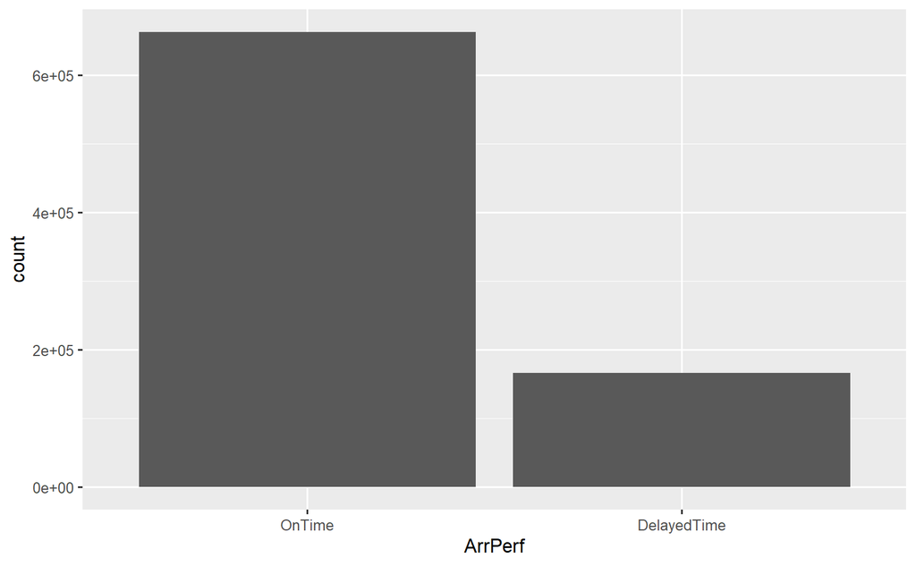

```r
airline %>% ggplot(aes(x= ArrPerf)) +
  geom_bar()
```

This shows that the overwhelming amount of the flights were indeed on-time in this data set.

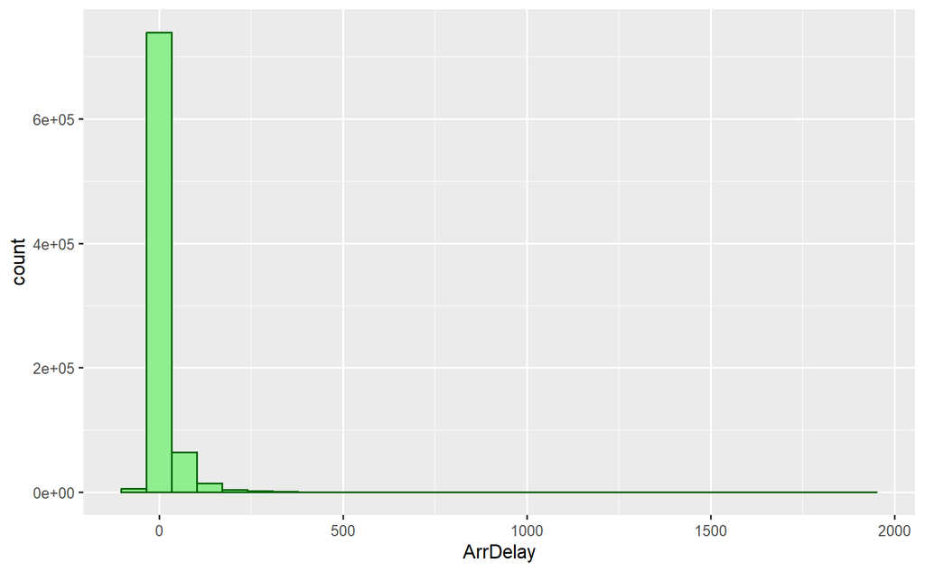

```r
arrHist <- ggplot(airline, aes(x = ArrDelay)) +
  geom_histogram(color = "darkgreen", fill = "lightgreen")

arrHist
```

As we can see most of the data is skewed right which means that the majority of the data is less than the mean.

Now lets attempt to look at the histograms in regards to the most popular airlines. To start, I will look at all of the unique airlines in this data set: